# Pertemuan 8 - Kelompok 15

Lutfi Syahreza Lubis

Reyzha Siva Dewi

Oktavia Galih Pratiwi

Aisyah Nuruzzahra Tirtasuwanda

## Packages

```r
library(ggplot2)
library(tsibble)
library(tseries)
library(MASS)
library(forecast)
library(TSA)
library(TTR)
library(aTSA)
library(graphics)
```

## Input Data

```r
data <- rio::import("https://raw.githubusercontent.com/oktaviagalihpratiwi/praktikum-mpdwokta/main/Pertemuan%208/Jumlah-Penumpang-Kereta-Api.csv")
data <- data[1:105,]
dim(data)
```

```
## [1] 105   3
```

```r
head(data)
```

```
##         Periode Nomor Jumlah Penumpang KAI Jawa
## 1  Januari 2011     1                     16446
## 2 Februari 2011     2                     14519
## 3    Maret 2011     3                     16584
## 4        Apr-11     4                     16031
## 5      Mei 2011     5                     17018
## 6     Juni 2011     6                     16806
```

```r
data.ts <- data$`Jumlah Penumpang KAI Jawa`
data.ts <- ts(data.ts)
```

## Eksplorasi

### Plot Data Penuh

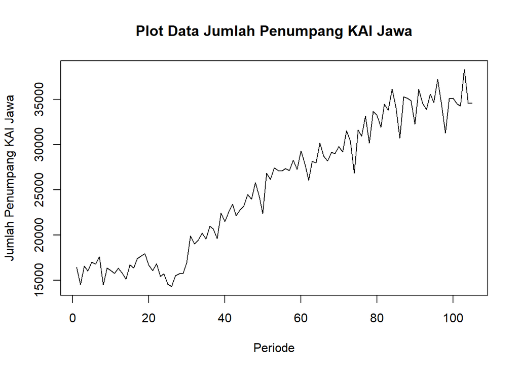

```r
plot.ts(data.ts, lty=1, xlab="Periode", ylab="Jumlah Penumpang KAI Jawa", main="Plot Data Jumlah Penumpang KAI Jawa")
```

Berdasarkan plot data di atas, terlihat bahwa data cenderung memiliki tren naik. Selanjutnya, berdasarkan plot, data akan dilakukan proporsi/perbandingan, yaitu 80:20.

### Pembagian Data

```r
data.train <- data$`Jumlah Penumpang KAI Jawa`[1:84]
train.ts <- ts(data.train)
data.test <- data$`Jumlah Penumpang KAI Jawa`[85:105]
test.ts <- ts(data.test)
```

### Plot Data Latih

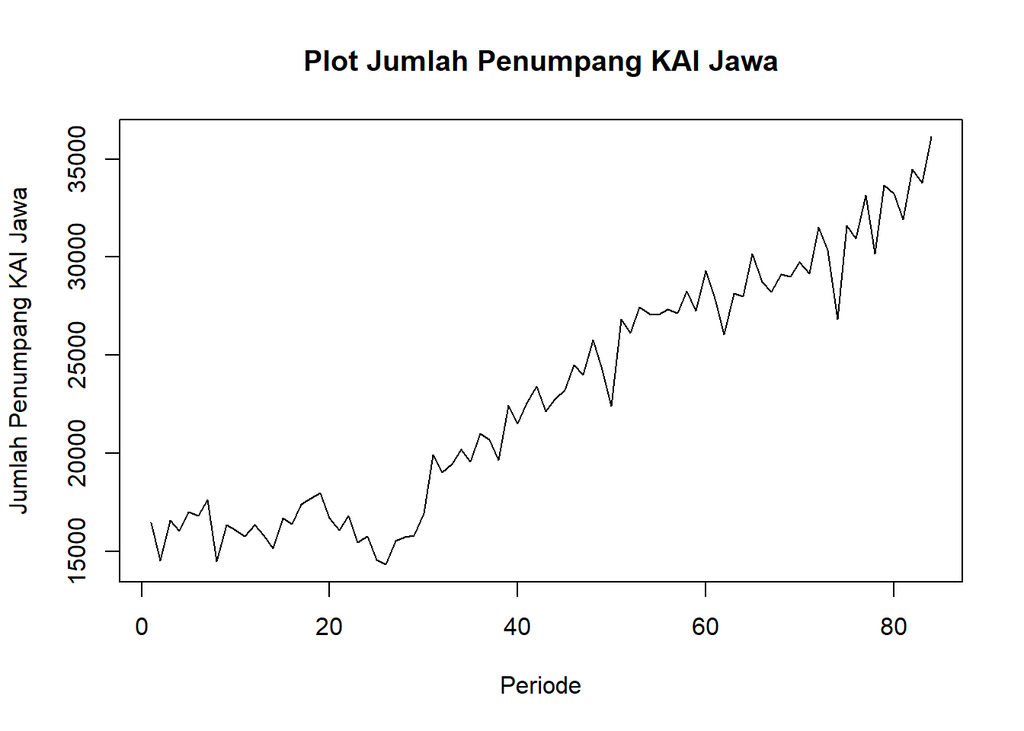

```r
plot.ts(train.ts, lty=1, xlab="Periode", ylab="Jumlah Penumpang KAI Jawa", main="Plot Jumlah Penumpang KAI Jawa")
```

Berdasarkan plot data tersebut, terlihat bahwa data cenderung tidak stasioner dalam nilai tengah maupun ragam.

### Plot Data Uji

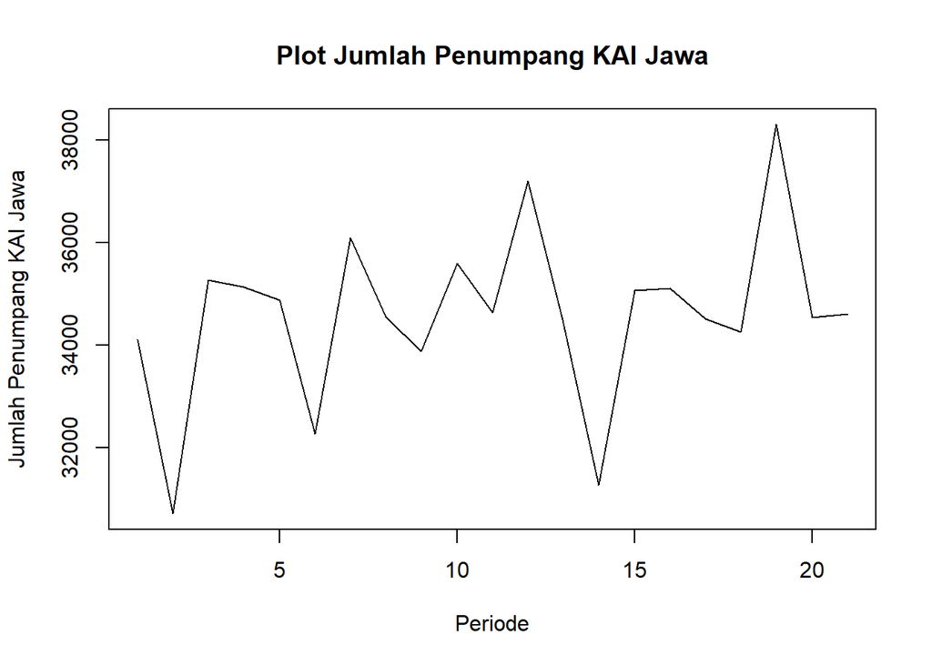

```r
plot.ts(test.ts, lty=1, xlab="Periode", ylab="Jumlah Penumpang KAI Jawa", main="Plot Jumlah Penumpang KAI Jawa")
```

## Uji Stasioneritas Data

### Plot ACF

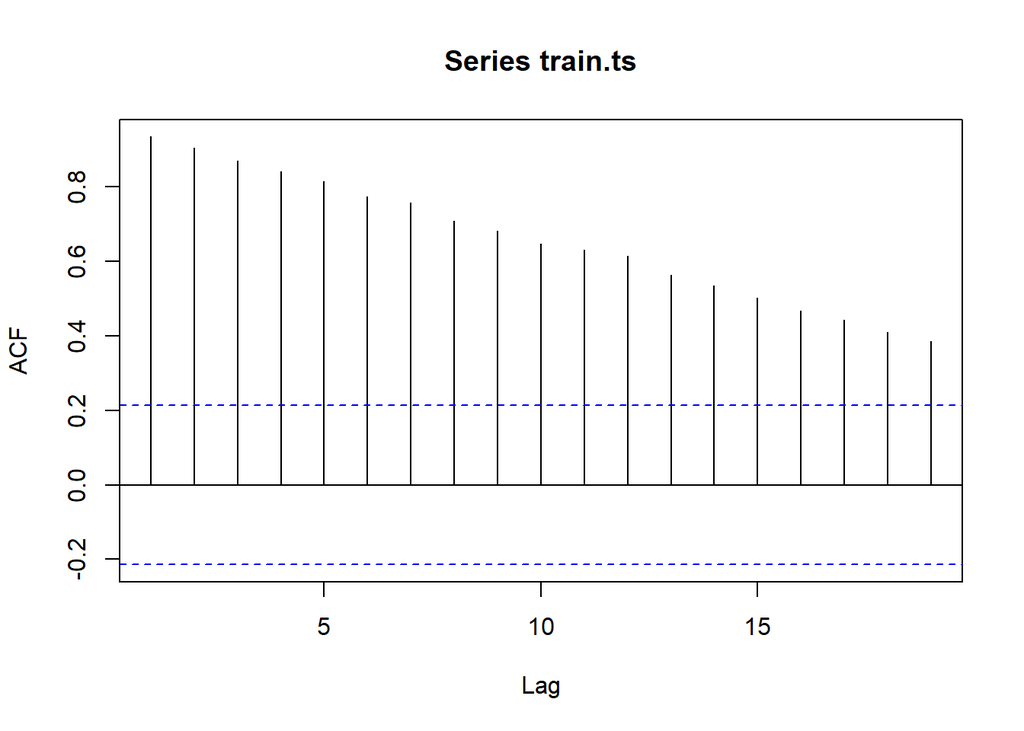

```r
acf(train.ts)
```

Terlihat bahwa plot ACF menuruh secara perlaha atau *tails of slowly*. Artinya, data tidak stasioner dalam rataan.

### Uji ADF

```r
tseries::adf.test(test.ts)
```

```
##
##  Augmented Dickey-Fuller Test
##
## data:  test.ts
## Dickey-Fuller = -3.2514, Lag order = 2, p-value = 0.09842
## alternative hypothesis: stationary
```

$H_0$ : Data tidak stasioner dalam rataan

$H_1$ : Data stasioner dalam rataan

Didapatkan nilai *p-value* sebesar 0.09842 yang lebih besar dari taraf nyata 5% sehingga tak tolak $H_0$. Artinya, data tidak stasioner dalam rataan. Hasil ini, sesuai denga hasil eksplorasi menggunakan plot time series dan plot ACF sehingga perlu ditangani.

### Plot Box-Cox

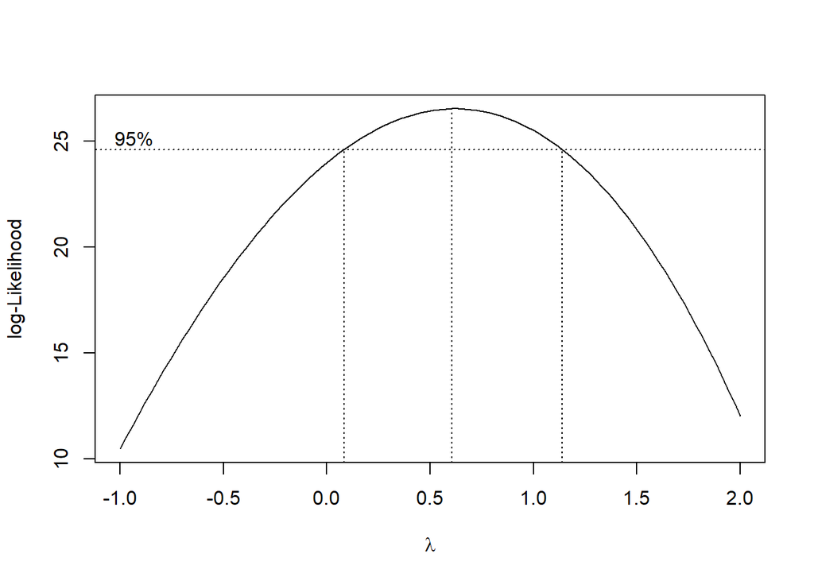

```r
index <- seq(1:84)
bc = boxcox(train.ts~index, lambda = seq(-1,2,by=1))
```

```r
#Nilai Rounded Lambda
lambda <- bc$x[which.max(bc$y)]
lambda
```

```
## [1] 0.6060606
```

```r
#SK
bc$x[bc$y > max(bc$y) - 1/2 * qchisq(.95,1)]
```

```
##  [1] 0.09090909 0.12121212 0.15151515 0.18181818 0.21212121 0.24242424
##  [7] 0.27272727 0.30303030 0.33333333 0.36363636 0.39393939 0.42424242
## [13] 0.45454545 0.48484848 0.51515152 0.54545455 0.57575758 0.60606061
## [19] 0.63636364 0.66666667 0.69696970 0.72727273 0.75757576 0.78787879
## [25] 0.81818182 0.84848485 0.87878788 0.90909091 0.93939394 0.96969697
## [31] 1.00000000 1.03030303 1.06060606 1.09090909 1.12121212
```

Plot Box-Cox menunjukkan nilai *rounded value* ($\lamda$) optimum sebesar 0.60606 dan pada selang kepercayaan 95% yang memiliki batas bawah 0.0909 dan batas atas 1.12121. Selang tersebut mengandung nilai satu sehingga data stasioner dalam ragam.

## Penanganan Ketidakstasioneran Data

```r
train.diff<-diff(train.ts,differences = 1)
train.diff
```

```
## Time Series:
## Start = 2
## End = 84
## Frequency = 1
##  [1] -1927  2065  -553   987  -212   826 -3140  1861  -291  -297   568  -532
## [13]  -675  1575  -325  1025   286   269 -1281  -612   765 -1392   309 -1172
## [25]  -258  1206   203    71  1137  2985  -886   408   759  -620  1414  -294
## [37] -1070  2799  -925  1045   868 -1290   638   456  1284  -517  1805 -1537
## [49] -1860  4447  -691  1300  -332   -41   274  -226  1155 -1027  2075 -1442
## [61] -1828  2098  -156  2176 -1446  -514   909  -106   746  -587  2352 -1171
## [73] -3522  4775  -678  2223 -2976  3488  -414 -1334  2577  -700  2342
```

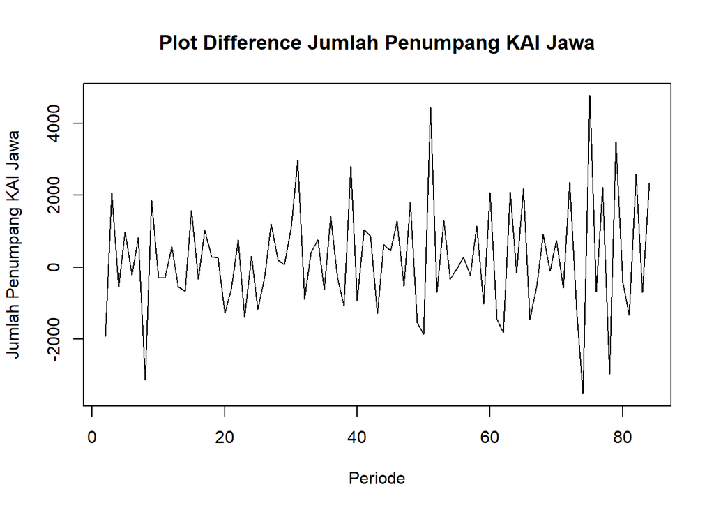

```r
plot.ts(train.diff, lty=1, xlab="Periode", ylab="Jumlah Penumpang KAI Jawa", main="Plot Difference Jumlah Penumpang KAI Jawa")
```

Berdasarkan plot, terlihat bahwa data sudah stasioner dalam rataan ditandai dengan data bergerak pada nilai tengah tertentu. Tidak terdapat trend ataupun musiman pada data.

### Plot ACF

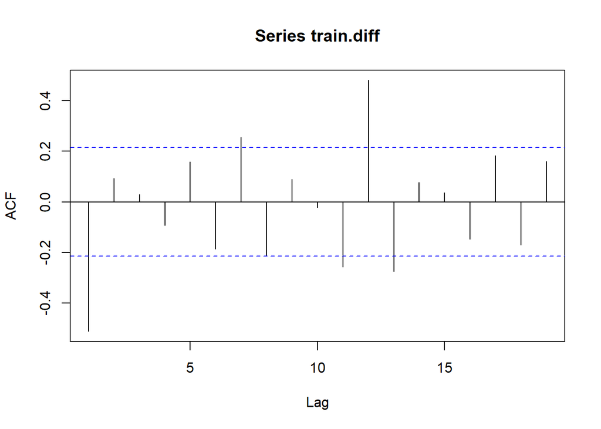

```r
acf(train.diff)
```

Berdasarkan plot, terlihat bahwa ACF *cuts off* pada lag ke 1. Hal ini menandakan data sudah stasioner dalam rataan dan ketidakstasioneran data telah berhasil tertangani.

### Uji ADF

```r
tseries::adf.test(train.diff)
```

```
##
##  Augmented Dickey-Fuller Test
##
## data:  train.diff
## Dickey-Fuller = -4.5576, Lag order = 4, p-value = 0.01
## alternative hypothesis: stationary
```

$H_0$ : Data tidak stasioner dalam rataan

$H_1$ : Data stasioner dalam rataan

Berdasarkan uji ADF, didapatkan *p-value* sebesar 0.01 nilai tersebut lebih kecil dari taraf nyata 5% sehingga tolak $H_0$ atau data stasioner dalam rataan. Data sudah bisa dinyatakan stasioner sehingga dapat dilanjutkan ke pemodelan.

## Identifikasi Model

### Plot ACF

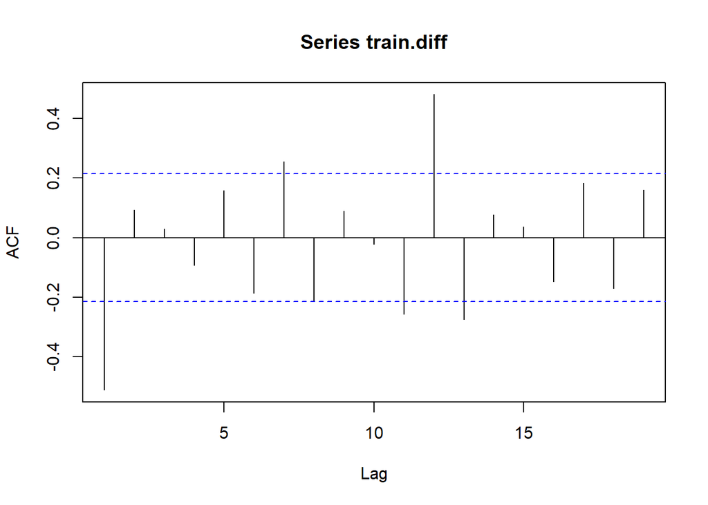

```r
acf(train.diff)
```

Berdasarkan plot, terlihat bahwa plot ACF cenderung *cuts off* pada lag ke 1, sehingga jika plot PACF dianggap *tails off*, maka model tentatifnya adalah ARIMA(0,1,1).

### Plot PACF

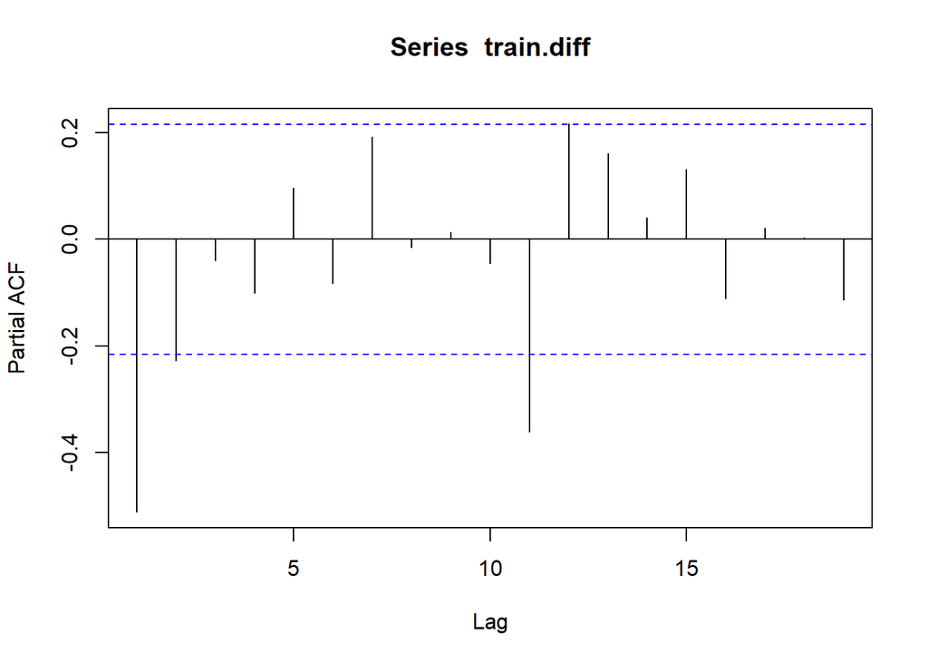

```r
pacf(train.diff)
```

### Plot EACF

```r
eacf(train.diff)
```

```
## AR/MA
##   0 1 2 3 4 5 6 7 8 9 10 11 12 13
## 0 x o o o o o x o o o x  x  x  o
## 1 x o o o o o o o o o o  x  o  o
## 2 x o o o o o o o o o o  x  o  o
## 3 x x o o o o o o o o o  x  o  o
## 4 x o o o o o o o o o o  x  o  o
## 5 x o o o o o o o o o o  x  o  o
## 6 x o o x o o o o o o o  x  o  o
## 7 o o x o o o o o o o o  x  o  o
```

Identifikasi model menggunakan plot EACF dilakukan dengan melihat ujung segitiga pada pola segitiga nol. Dari hasil tersebut, model tentatif yang terbentuk adalah ARIMA (2,1,1), ARIMA(0,1,1), dan ARIMA(3,1,2).

## Pendugaan Parameter Model Tentatif

### ARIMA(2,1,1)

```r
model1.da=Arima(train.diff, order=c(2,1,1),method="ML")
summary(model1.da) #AIC=1422.32
```

```
## Series: train.diff
## ARIMA(2,1,1)
##
## Coefficients:
##           ar1      ar2      ma1
##       -0.6443  -0.2305  -0.9737
## s.e.   0.1099   0.1107   0.0493
##
## sigma^2 = 1778201:  log likelihood = -707.16
## AIC=1422.32   AICc=1422.84   BIC=1431.95
##
## Training set error measures:
##                    ME     RMSE      MAE      MPE     MAPE      MASE        ACF1
## Training set 173.5678 1300.963 983.5541 77.25647 115.3741 0.4585464 -0.02635301
```

```r
lmtest::coeftest(model1.da) #seluruh parameter signifikan
```

```
##
## z test of coefficients:
##
##      Estimate Std. Error  z value  Pr(>|z|)
## ar1 -0.644345   0.109858  -5.8652 4.485e-09 ***
## ar2 -0.230496   0.110700  -2.0822   0.03733 *
## ma1 -0.973654   0.049267 -19.7629 < 2.2e-16 ***
## ---
## Signif. codes:  0 '***' 0.001 '**' 0.01 '*' 0.05 '.' 0.1 ' ' 1
```

### ARIMA (0,1,1)

```r
model2.da=Arima(train.diff, order=c(0,1,1),method="ML")
summary(model2.da) #AIC=1447.53
```

```
## Series: train.diff
## ARIMA(0,1,1)
##
## Coefficients:
##          ma1
##       -1.000
## s.e.   0.039
##
## sigma^2 = 2481993:  log likelihood = -721.77
## AIC=1447.53   AICc=1447.69   BIC=1452.35
##
## Training set error measures:
##                    ME     RMSE      MAE      MPE     MAPE      MASE       ACF1
## Training set 161.6482 1556.337 1212.072 111.1291 111.1291 0.5650845 -0.5045934
```

```r
lmtest::coeftest(model2.da) #seluruh parameter signifikan
```

```
##
## z test of coefficients:
##
##      Estimate Std. Error z value  Pr(>|z|)
## ma1 -1.000000   0.038952 -25.672 < 2.2e-16 ***
## ---
## Signif. codes:  0 '***' 0.001 '**' 0.01 '*' 0.05 '.' 0.1 ' ' 1
```

### ARIMA(3,1,2)

```r
model3.da=Arima(train.diff, order=c(3,1,2),method="ML")
summary(model3.da) #AIC=1425.73
```

```
## Series: train.diff
## ARIMA(3,1,2)
##
## Coefficients:
##           ar1      ar2     ar3      ma1     ma2
##       -0.2617  -0.0255  0.0120  -1.3749  0.3994
## s.e.   0.6649   0.4494  0.2097   0.6521  0.6327
##
## sigma^2 = 1814518:  log likelihood = -706.87
## AIC=1425.73   AICc=1426.85   BIC=1440.17
##
## Training set error measures:
##                    ME     RMSE      MAE      MPE    MAPE      MASE        ACF1
## Training set 166.2938 1297.439 983.6968 83.45606 117.653 0.4586129 -0.01242123
```

```r
lmtest::coeftest(model3.da) #hanya ma1 yang berpengaruh signifikan
```

```
##
## z test of coefficients:
##
##      Estimate Std. Error z value Pr(>|z|)
## ar1 -0.261680   0.664935 -0.3935  0.69392
## ar2 -0.025487   0.449356 -0.0567  0.95477
## ar3  0.012011   0.209707  0.0573  0.95433
## ma1 -1.374902   0.652061 -2.1085  0.03498 *
## ma2  0.399407   0.632665  0.6313  0.52784
## ---
## Signif. codes:  0 '***' 0.001 '**' 0.01 '*' 0.05 '.' 0.1 ' ' 1
```

### ARIMA(2,1,0)

```r
model3.da=Arima(train.diff, order=c(2,1,0),method="ML")
summary(model3.da) #AIC=1453.78
```

```
## Series: train.diff
## ARIMA(2,1,0)
##
## Coefficients:
##           ar1     ar2
##       -1.0702  -0.528
## s.e.   0.0936   0.094
##
## sigma^2 = 2748332:  log likelihood = -723.89
## AIC=1453.78   AICc=1454.09   BIC=1461
##
## Training set error measures:
##                    ME     RMSE      MAE      MPE     MAPE      MASE       ACF1
## Training set 58.82887 1627.573 1233.483 38.92922 157.8275 0.5750667 -0.1534522
```

```r
lmtest::coeftest(model3.da) #semua parameter berpengaruh signifikan
```

```
##
## z test of coefficients:
##
##      Estimate Std. Error  z value  Pr(>|z|)
## ar1 -1.070250   0.093553 -11.4401 < 2.2e-16 ***
## ar2 -0.527977   0.093995  -5.6171 1.942e-08 ***
## ---
## Signif. codes:  0 '***' 0.001 '**' 0.01 '*' 0.05 '.' 0.1 ' ' 1
```

Berdasarkan pendugaan parameter di atas, nilai AIC terkecil dan seluruhnya signifikan sehingga model yang dipilih adala model ARIMA(2,1,1).

## Analisis Sisaan

Model terbaik hasil identifikasi kemudian dicek asumsi sisaannya. Sisaan model ARIMA harus memenuhi asumsi normalitas, kebebasan sisaan, dan kehomogenan ragam. Diagnostik model dilakukan secara eksplorasi dan uji formal.

### Eksplorasi Sisaan

#### Eksplorasi

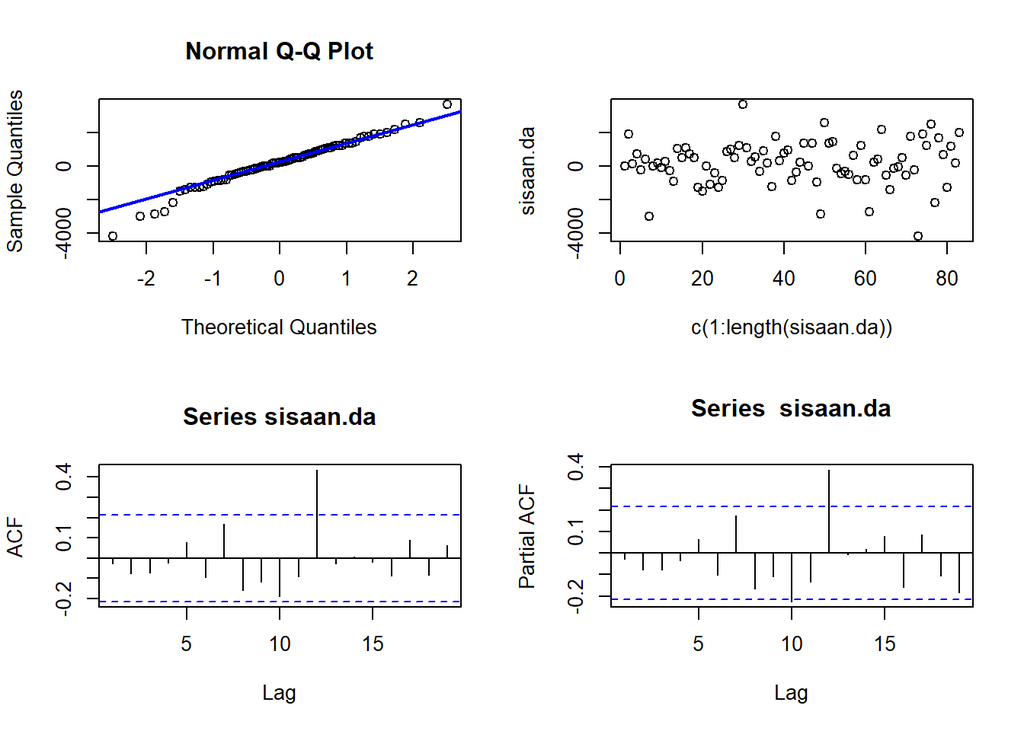

```r
sisaan.da <- model1.da$residuals
par(mfrow=c(2,2))
qqnorm(sisaan.da)
qqline(sisaan.da, col = "blue", lwd = 2)
plot(c(1:length(sisaan.da)),sisaan.da)
acf(sisaan.da)
pacf(sisaan.da)
```

## Uji Formal

### Sisaan Menyebar Normal

```r
ks.test(sisaan.da,"pnorm")
```

```
##
##  Exact one-sample Kolmogorov-Smirnov test
##
## data:  sisaan.da
## D = 0.59036, p-value < 2.2e-16
## alternative hypothesis: two-sided
```

$H_0$ : Sisaan menyebar normal

$H_1$ : Sisaan tidak menyebar normal

Berdasarkan uji Kolmogorov-Smirnov, didapatkan *p-value* sebesar 2.2e-16 yang kurang dari taraf nyata 5% sehingga tolak $H_0$ dan menandakan bahwa sisaan tidak menyebar normal. Hal ini memiliki hasil yang berbeda dari eksplorasi dengan plot.

### Sisaan Saling Bebas/Tidak Ada Autokorelasi

```r
Box.test(sisaan.da, type = "Ljung")
```

```
##
##  Box-Ljung test
##
## data:  sisaan.da
## X-squared = 0.059751, df = 1, p-value = 0.8069
```

$H_0$ : Sisaan saling bebas

$H_1$ : Sisaan tidak tidak saling bebas

Berdasarkan uji Ljung-Box, didapatkan nilai *p-value* sebesar 0.8069 yang lebih besar dari taraf nyata 5% sehingga tak tolak $H_0$ . Artinya, sisaan saling bebas.

### Sisaan Homogen

```r
Box.test((sisaan.da)^2, type = "Ljung")
```

```
##
##  Box-Ljung test
##
## data:  (sisaan.da)^2
## X-squared = 0.21763, df = 1, p-value = 0.6408
```

$H_0$ : Ragam sisaan homogen

$H_1$ : Ragam sisaan tidak homogen

### Nilai Tengah Sisaan Sama Dengan Nol

```r
t.test(sisaan.da, mu = 0, conf.level = 0.95)
```

```
##
##  One Sample t-test
##
## data:  sisaan.da
## t = 1.219, df = 82, p-value = 0.2263
## alternative hypothesis: true mean is not equal to 0
## 95 percent confidence interval:
##  -109.6773  456.8129
## sample estimates:
## mean of x
##  173.5678
```

$H_0$ : nilai tengah sisaan sama dengan 0

$H_1$ : nilai tengah sisaan tidak sama dengan 0

Berdasarkan uji-ttersebut, didapat *p-value* sebesar 0.2263 yang lebih besar dari taraf nyata 5% sehingga tak tolak $H_0$ dan menandakan bahwa nilai tengah sisaan sama dengan nol.

## Overfitting

Tahapan selanjutnya adalah *overfitting* dilakukan dengan menaikkan orde AR(p) dan MA(q) dari model ARIMA(2,1,1) untuk melihat apakah terdapat model lain yang lebih baik dari model saat ini. Kandidat model *overfitting* adalah ARIMA(3,1,1) dan ARIMA(2,1,2).

### Model ARIMA(3,1,1)

```r
model.overfit1=Arima(train.diff, order=c(3,1,1),method="ML")
summary(model.overfit1) #1424.03
```

```
## Series: train.diff
## ARIMA(3,1,1)
##
## Coefficients:
##           ar1      ar2      ar3      ma1
##       -0.6638  -0.2739  -0.0627  -0.9677
## s.e.   0.1154   0.1368   0.1163   0.0493
##
## sigma^2 = 1795942:  log likelihood = -707.02
## AIC=1424.03   AICc=1424.82   BIC=1436.06
##
## Training set error measures:
##                    ME     RMSE      MAE      MPE     MAPE      MASE        ACF1
## Training set 170.7686 1299.135 985.4119 84.36567 119.2179 0.4594126 -0.01993739
```

```r
lmtest::coeftest(model.overfit1) #ar3 tidak berpengaruh signifikan
```

```
##
## z test of coefficients:
##
##      Estimate Std. Error  z value  Pr(>|z|)
## ar1 -0.663804   0.115402  -5.7521 8.814e-09 ***
## ar2 -0.273947   0.136752  -2.0032   0.04515 *
## ar3 -0.062734   0.116328  -0.5393   0.58969
## ma1 -0.967688   0.049255 -19.6467 < 2.2e-16 ***
## ---
## Signif. codes:  0 '***' 0.001 '**' 0.01 '*' 0.05 '.' 0.1 ' ' 1
```

### Model ARIMA (2,1,2)

```r
model.overfit2=Arima(train.diff, order=c(2,1,2),method="ML")
summary(model.overfit2) #1423.74
```

```
## Series: train.diff
## ARIMA(2,1,2)
##
## Coefficients:
##           ar1      ar2      ma1     ma2
##       -0.2937  -0.0476  -1.3433  0.3689
## s.e.   0.3814   0.2413   0.3691  0.3642
##
## sigma^2 = 1791243:  log likelihood = -706.87
## AIC=1423.74   AICc=1424.53   BIC=1435.77
##
## Training set error measures:
##                    ME     RMSE      MAE      MPE     MAPE      MASE        ACF1
## Training set 166.3105 1297.435 984.0674 83.91068 118.0288 0.4587857 -0.01265901
```

```r
lmtest::coeftest(model.overfit2) #hanya ma3 yang signifikan
```

```
##
## z test of coefficients:
##
##      Estimate Std. Error z value  Pr(>|z|)
## ar1 -0.293708   0.381414 -0.7701 0.4412702
## ar2 -0.047591   0.241308 -0.1972 0.8436557
## ma1 -1.343295   0.369097 -3.6394 0.0002733 ***
## ma2  0.368939   0.364230  1.0129 0.3110940
## ---
## Signif. codes:  0 '***' 0.001 '**' 0.01 '*' 0.05 '.' 0.1 ' ' 1
```

Berdasarkan hasil AIC dan parameter, model sebelum overfitting merupakan model yang paling baik karena memiliki nilai AIC terkecil dan semua parameternya berpengaruh. Oleh karena itu, model yang dipilih adalah ARIMA (2,1,1).

## Peramalan

Peramalan berikut ini dilakukan untuk 27 hari ke depan.

```r
ramalan.da <- forecast::forecast(model1.da, h = 27)
ramalan.da
```

```
##     Point Forecast     Lo 80     Hi 80     Lo 95    Hi 95
##  85      -812.2322 -2521.741  897.2764 -3426.700 1802.236
##  86       519.0142 -1489.994 2528.0224 -2553.499 3591.527
##  87       388.2686 -1648.006 2424.5431 -2725.944 3502.482
##  88       165.6675 -1871.995 2203.3300 -2950.668 3282.003
##  89       339.2357 -1699.949 2378.4204 -2779.428 3457.900
##  90       278.7065 -1762.027 2319.4403 -2842.326 3399.739
##  91       277.7015 -1763.066 2318.4695 -2843.384 3398.787
##  92       292.3008 -1748.552 2333.1537 -2828.914 3413.516
##  93       283.1255 -1757.951 2324.2015 -2838.431 3404.682
##  94       285.6725 -1755.514 2326.8591 -2836.053 3407.398
##  95       286.1462 -1755.186 2327.4782 -2835.802 3408.094
##  96       285.2539 -1756.224 2326.7320 -2836.918 3407.425
##  97       285.7196 -1755.896 2327.3350 -2836.662 3408.101
##  98       285.6252 -1756.133 2327.3833 -2836.974 3408.225
##  99       285.5787 -1756.321 2327.4779 -2837.237 3408.394
## 100       285.6304 -1756.410 2327.6706 -2837.400 3408.661
## 101       285.6078 -1756.574 2327.7894 -2837.639 3408.855
## 102       285.6105 -1756.712 2327.9331 -2837.853 3409.073
## 103       285.6140 -1756.850 2328.0778 -2838.065 3409.293
## 104       285.6111 -1756.994 2328.2161 -2838.284 3409.506
## 105       285.6121 -1757.134 2328.3583 -2838.499 3409.723
## 106       285.6121 -1757.275 2328.4995 -2838.714 3409.939
## 107       285.6119 -1757.417 2328.6404 -2838.931 3410.154
## 108       285.6120 -1757.558 2328.7817 -2839.146 3410.370
## 109       285.6120 -1757.699 2328.9227 -2839.362 3410.586
## 110       285.6120 -1757.840 2329.0639 -2839.578 3410.802
## 111       285.6120 -1757.981 2329.2050 -2839.794 3411.018
```

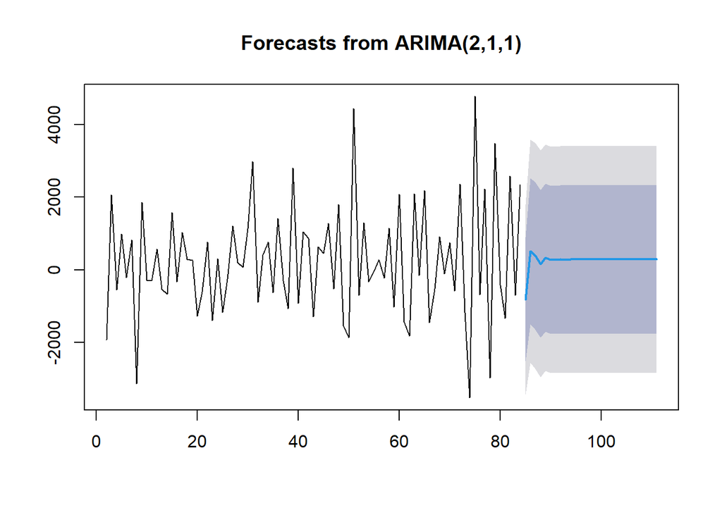

```r
data.ramalan.da <- ramalan.da$mean
plot(ramalan.da)
```

Berdasarkan hasil plot ramalan di atas, dapat dilihat bahwa ramalan ARIMA(2,1,1) cenderung stabil hingga akhir periode. Selanjutnya, dapat dicari nilai akurasi antara hasil ramalan dengan data uji sebagai berikut.

```r
pt_1 <- train.ts[84] #nilai akhir data latih
hasil.forc.Diff <- data.ramalan.da
hasil <- diffinv(hasil.forc.Diff, differences = 1) + pt_1
hasil
```

```
## Time Series:
## Start = 84
## End = 111
## Frequency = 1
##  [1] 36140.00 35327.77 35846.78 36235.05 36400.72 36739.95 37018.66 37296.36
##  [9] 37588.66 37871.79 38157.46 38443.61 38728.86 39014.58 39300.21 39585.78
## [17] 39871.41 40157.02 40442.63 40728.25 41013.86 41299.47 41585.08 41870.69
## [25] 42156.31 42441.92 42727.53 43013.14
```

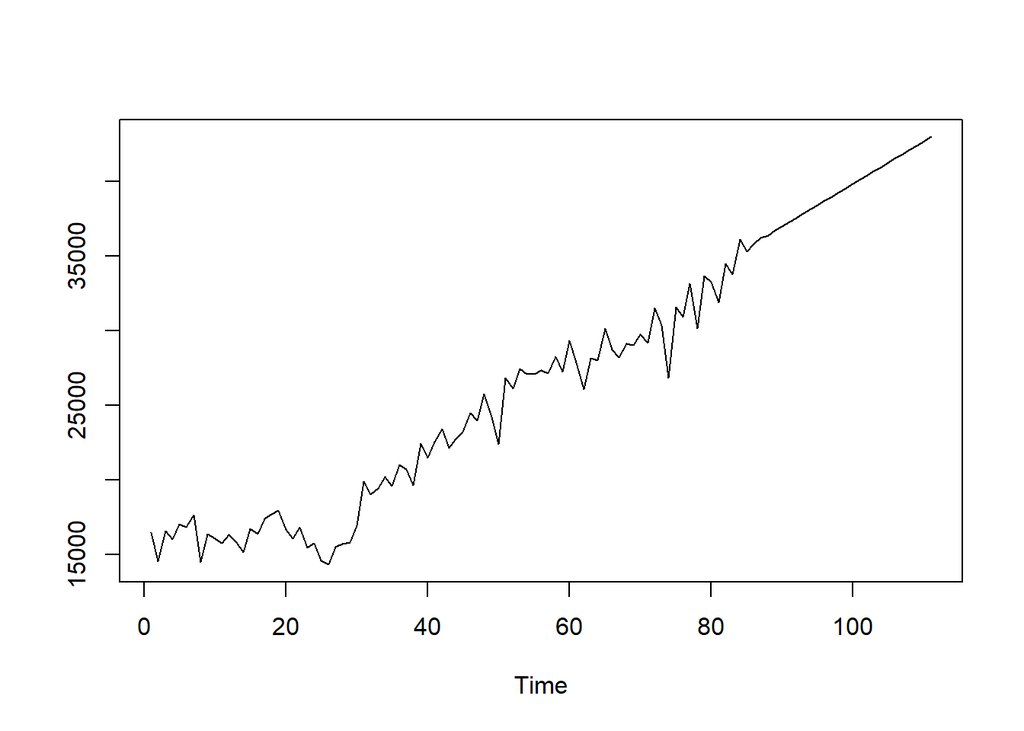

```r
#has.1 sama hasilnya dengan: cumsum(c(pt_1,hasil.forc.Diff))
ts.plot(train.ts,hasil)
```

```r
perbandingan.da<-matrix(data=c(head(test.ts, n=27), hasil[-1]),
                     nrow = 27, ncol = 2)
colnames(perbandingan.da)<-c("Aktual","Hasil Forecast")
perbandingan.da
```

```
##         Aktual Hasil Forecast
##  [1,] 34107.00       37296.36
##  [2,] 30721.00       37588.66
##  [3,] 35272.00       37871.79
##  [4,] 35135.00       38157.46
##  [5,] 34877.00       38443.61
##  [6,] 32270.00       38728.86
##  [7,] 36089.00       39014.58
##  [8,] 34560.00       39300.21
##  [9,] 33878.00       39585.78
## [10,] 35602.00       39871.41
## [11,] 34637.00       40157.02
## [12,] 37197.00       40442.63
## [13,] 34435.00       40728.25
## [14,] 31282.00       41013.86
## [15,] 35068.00       41299.47
## [16,] 35106.00       41585.08
## [17,] 34514.00       41870.69
## [18,] 34261.00       42156.31
## [19,] 38303.00       42441.92
## [20,] 34542.00       42727.53
## [21,] 34615.00       43013.14
## [22,] 35327.77       34107.00
## [23,] 35846.78       30721.00
## [24,] 36235.05       35272.00
## [25,] 36400.72       35135.00
## [26,] 36739.95       34877.00
## [27,] 37018.66       32270.00
```

```r
accuracy(ts(hasil[-1]), head(test.ts, n=27))
```

```
##                 ME     RMSE      MAE       MPE     MAPE      ACF1 Theil's U
## Test set -3837.995 4348.786 3837.995 -11.28561 11.28561 0.1634754  1.681193
```

Dari hasil diperoleh nilai MAPE 11.28561, model tersebut baik untuk menggambarkan model deret waktu.